# Example Notebook

The optimization framework is suited for data analytics use cases where customers are to be targeted for marketing / communication material in order to drive conversion rates across a range of different products.

This notebook contains an example run of the optimization framework.

## Installs

These essential libraries are required to be installed to run this notebook.

```python
!pip install pandas
```

```python
!pip install matplotlib
```

## Imports

Necessary imports to run the code.

```python
import numpy as np
import pandas as pd
import matplotlib.pyplot as plt
```

```python
from smart_segment import find_optimal_bins
```

## Data

We create sample data to simulate the results of a binary classification / propensity model.

As common with unbalanced datasets, we create the dataframe skewed towards the negative class, with very few positive labels. As a result, the `Gamma distribution` is used to simulate these values.

The true labels `y` generated are meant to indicate the outcome obtained after the implementation period on the user conversions.

```
Propensities:  (100000,)
```

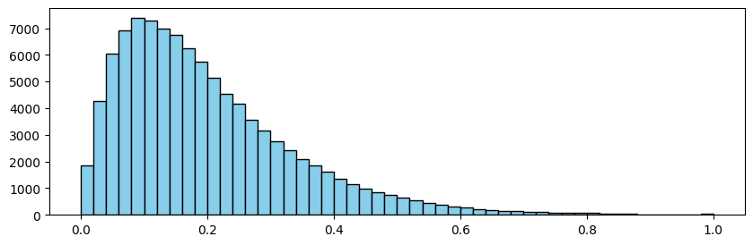

```python
# Seed to ensure consistency
np.random.seed(42)

# Gamma Distribution parameters and data size
k, theta = 2, 2
size = 100_000

# Generating Gamma values within 0-1
gamma_values = np.random.gamma(k ,theta, size)
propensities = np.sort(np.clip(gamma_values, 0, 20)/20.0)
print('Propensities: ', propensities.shape)

plt.figure(figsize=(10,3))
plt.hist(propensities, bins=50, color='skyblue', edgecolor='black')
plt.show()
```

```python
# Creating the DataFrame
df = pd.DataFrame(propensities, columns=['propensity'])

# Simulating the true binary outcome
df['y'] = df['propensity'].apply(lambda s: np.random.choice([0, 1], p=[1-s, s]))

df.sample(5)
```

|  | propensity | y |
| --- | --- | --- |
| 7623 | 0.045884 | 0 |
| 14124 | 0.066294 | 0 |
| 67941 | 0.234862 | 0 |
| 84003 | 0.329847 | 0 |
| 66970 | 0.230598 | 1 |

## Segmentation Algorithms

Common segmentation algorithms usually include uniform splits or percentile based splits. Here we introduce our optimization based split to segment customers.

All 3 segmenting algorithms are performed on the dataset.

```python
# Uniform segment
df['uniform'] = pd.cut(df['propensity'], 10)

# Percentile segment
df['percentile'] = pd.qcut(df['propensity'], 10, duplicates='drop')

df.sample(5)
```

|  | propensity | y | uniform | percentile |
| --- | --- | --- | --- | --- |
| 89308 | 0.381409 | 0 | (0.3, 0.4] | (0.3, 0.39] |
| 78280 | 0.288872 | 0 | (0.2, 0.3] | (0.244, 0.3] |
| 85543 | 0.342699 | 1 | (0.3, 0.4] | (0.3, 0.39] |
| 98092 | 0.589863 | 0 | (0.5, 0.6] | (0.39, 1.0] |
| 43852 | 0.149389 | 0 | (0.1, 0.2] | (0.138, 0.168] |

### Optimization

The optimization algorithm aims to find the optimum number of splits as well as the boundaries for each split maximizing objective functions.

The model has its algorithm relying on the objective function, which requires the cost and revenue incurred for each user. This allows for providing cost and revenue functions using the index of the bin as a parameter. This was created with the idea that customers with higher probabilities might require more specialized communication material thus incurring a higher cost, and vice versa.

The revenue function used is a constant value for all customers: `lambda ix: 30`.

The cost function used depends on the bin index increasing monotonicallt: `lambda ix: 2*ix`.

A penalty factor can be used when the model is stuckon local minimas to push further exploration. In this example, we set it to 0.

The maximized equation is `Revenue of Converted Customers - Cost of All Customers - Exploitation Penalty`.

- Cost function to determine the cost of marketing to each customer within that consumer group.
- Revenue function to determine the revenue gained from the conversion of a customer within that consumer group.
- Local minimum penalty factor (Penalty for not continuing exploration - used when results are not well distributed).

The optimization algorithm provides for several other configurable features:

- Number of splits to include
- Minimum number of samples per split
- Search method (Global / Quantile based)

```python
# Constant revenue across groups
revenue_fn = lambda ix: 30

# Variable cost across groups
cost_fn = lambda ix: 2*ix
```

```python
# Quantile Based (Pretty identical to Percentiles)
result = find_optimal_bins(df['propensity'], df['y'], n_bins=10,
                           revenue_fn=revenue_fn,
                           cost_fn=cost_fn,
                           penalty_factor=0,
                           min_samples=10, global_search=False)
best_n_bins, best_cutoffs, max_revenue = result
df['optim_quantile'] = pd.cut(df['propensity'], best_cutoffs, include_lowest=False, duplicates='drop')
```

```python
# Global Search
result = find_optimal_bins(df['propensity'], df['y'], n_bins=10,
                           revenue_fn=revenue_fn,
                           cost_fn=cost_fn,
                           penalty_factor=0,
                           min_samples=10, global_search=True)
best_n_bins, best_cutoffs, max_revenue = result
df['optim_global'] = pd.cut(df['propensity'], best_cutoffs, include_lowest=False, duplicates='drop')
```

```python
df.groupby('optim_global', observed=False)['y'].apply(lambda s: f'{len(s)}_{s.sum()/len(s)}').str.split('_', expand=True).rename(columns={0:'Count', 1:'Conversion_Rate'})
```

| optim_global | Count | Conversion_Rate |
| --- | --- | --- |
| (0.0, 0.154] | 45550 | 0.09119648737650933 |
| (0.154, 0.264] | 28435 | 0.20024617548795498 |
| (0.264, 0.406] | 17310 | 0.3200462160600809 |
| (0.406, 0.612] | 7165 | 0.48653175157013256 |
| (0.612, 0.898] | 1419 | 0.6990838618745595 |
| (0.898, 0.915] | 19 | 0.8947368421052632 |
| (0.915, 0.965] | 39 | 0.9743589743589743 |
| (0.965, 1.0] | 63 | 1.0 |

```python
df.head()
```

|  | propensity | y | uniform | percentile | optim_quantile | optim_global |
| --- | --- | --- | --- | --- | --- | --- |
| 0 | 0.000416 | 0 | (-0.000583, 0.1] | (-0.0005840000000000001, 0.0535] | (0.0, 0.0535] | (0.0, 0.154] |
| 1 | 0.000463 | 0 | (-0.000583, 0.1] | (-0.0005840000000000001, 0.0535] | (0.0, 0.0535] | (0.0, 0.154] |
| 2 | 0.000552 | 0 | (-0.000583, 0.1] | (-0.0005840000000000001, 0.0535] | (0.0, 0.0535] | (0.0, 0.154] |
| 3 | 0.000794 | 0 | (-0.000583, 0.1] | (-0.0005840000000000001, 0.0535] | (0.0, 0.0535] | (0.0, 0.154] |
| 4 | 0.000811 | 0 | (-0.000583, 0.1] | (-0.0005840000000000001, 0.0535] | (0.0, 0.0535] | (0.0, 0.154] |

```python
df.to_csv('segments.csv', index=False)
```

## Analysis

```python
def plot_stats(bin_df: pd.DataFrame, title: str):
    'Plotting the statistics'

    # Group counts by bins
    group_df = bin_df.groupby('bin', observed=True)['y'].agg(['count', 'sum']).reset_index(names='bins')

    # Calculate bin widths, conversions and indices
    group_df['conversion'] = group_df['sum'] / group_df['count']
    group_df['bin_width'] = group_df['bins'].apply(lambda x: x.right - x.left)
    group_df['bin_index'] = range(1, len(group_df)+1)

    # Calculate revenue per bin - costs
    group_df['incremental'] = (group_df['sum'] * group_df['bin_index'].apply(revenue_fn) -
                               group_df['count'] * group_df['bin_index'].apply(cost_fn))
    group_df['revenue_per_capita'] = group_df['incremental'] / group_df['count']

    # Normalize values for colors
    c_min, c_max = group_df['conversion'].min(), group_df['conversion'].max()
    group_df['color'] = (group_df['conversion'] - c_min) / (c_max - c_min)

    # Create Plot
    plt.figure(figsize=(20,8))
    cmap = plt.cm.RdYlGn

    # Set up tick labels and widths
    ws = group_df['bin_width']
    bins = group_df['bins']
    x_ticks = [sum(ws[:i]) + ws[i]/2 for i in range(len(ws))]
    tick_labels = sorted(set([round(float(y), 2) for x in bins for y in (x.left, x.right)]))

    # PLot Data
    convert_col = group_df['conversion'].copy()
    bars = plt.bar(x_ticks, height = group_df['count'], width = ws, color = cmap(convert_col), alpha = 0.8)
    plt.plot(x_ticks, group_df['sum'], color='black', marker='o', linestyle='-', label='Conversions')

    for i, bar in enumerate(bars):
        plt.text(bar.get_x() + bar.get_width() / 2, bar.get_height() + 100, f'{round(group_df.revenue_per_capita.iloc[i], 1)}$',
                 ha='center', va='bottom', fontsize=10, color='black')


    _ = plt.xticks(tick_labels, tick_labels, rotation=30, ha='right')
    plt.colorbar(plt.cm.ScalarMappable(cmap=cmap, norm=plt.Normalize(vmin=c_min, vmax=c_max)), ax=plt.gca(), label='Conversion Rate')
    plt.title(f'{title} Split - Conversion Rates & Revenue / Customer ($)')
    plt.tight_layout()

    plt.savefig(f'analyses/{title.lower().replace(" ", "_")}_plot.png', dpi=300, bbox_inches='tight')
    plt.show()

    return group_df
```

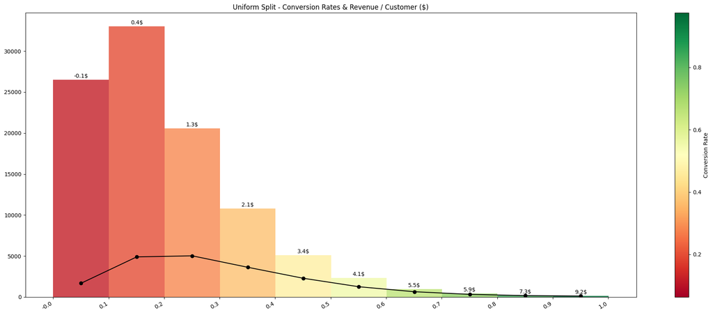

```python
uniform_df = plot_stats(df[['uniform', 'y']].rename(columns={'uniform': 'bin'}), 'Uniform')
```

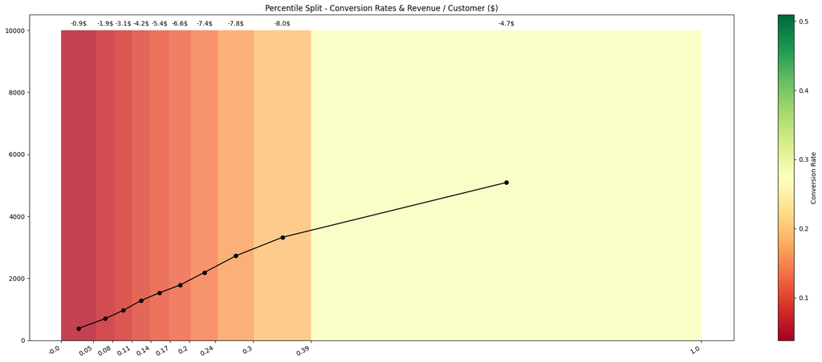

```python
percentile_df = plot_stats(df[['percentile', 'y']].rename(columns={'percentile': 'bin'}), 'Percentile')
```

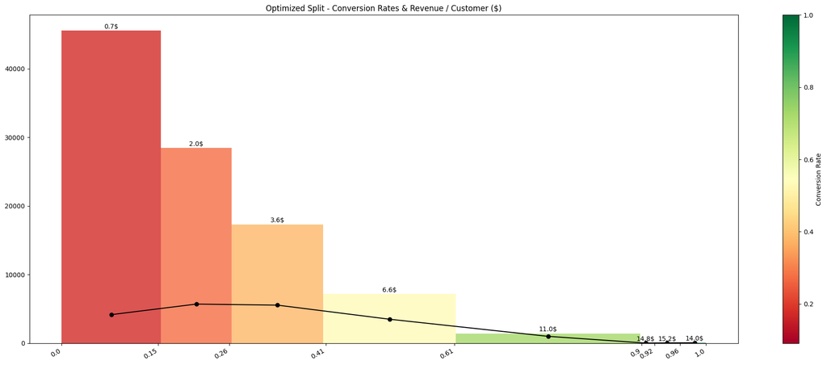

```python
optimized_df = plot_stats(df[['optim_global', 'y']].rename(columns={'optim_global': 'bin'}), 'Optimized')
```

```python
stat_dfs = {}

for stat_name in ['uniform', 'percentile', 'optimized']:
    stat_df = globals()[f'{stat_name}_df']
    stat_df = stat_df[['bins', 'count', 'sum', 'conversion', 'incremental', 'revenue_per_capita']]
    stat_df = stat_df.rename(columns={'bins': 'Split Group', 'count': '# of Customers',
                                      'sum': '# of Conversions', 'conversion': 'Converstion Rate',
                                      'incremental': 'Total Revenue ($)', 'revenue_per_capita': 'Revenue / Customer ($)'})
    stat_dfs[stat_name] = stat_df
    stat_df.to_csv(f'analyses/{stat_name}_stats.csv', index=False)
```

```python
stat_dfs['uniform']
```

|  | Split Group | # of Customers | # of Conversions | Converstion Rate | Total Revenue ($) | Revenue / Customer ($) |
| --- | --- | --- | --- | --- | --- | --- |
| 0 | (-0.000583, 0.1] | 26485 | 1673 | 0.063168 | -2780 | -0.104965 |
| 1 | (0.1, 0.2] | 33016 | 4892 | 0.148171 | 14696 | 0.445118 |
| 2 | (0.2, 0.3] | 20557 | 5021 | 0.244248 | 27288 | 1.327431 |
| 3 | (0.3, 0.4] | 10778 | 3624 | 0.336240 | 22496 | 2.087215 |
| 4 | (0.4, 0.5] | 5092 | 2282 | 0.448154 | 17540 | 3.444619 |
| 5 | (0.5, 0.6] | 2333 | 1250 | 0.535791 | 9504 | 4.073725 |
| 6 | (0.6, 0.7] | 984 | 640 | 0.650407 | 5424 | 5.512195 |
| 7 | (0.7, 0.8] | 439 | 320 | 0.728929 | 2576 | 5.867882 |
| 8 | (0.8, 0.9] | 197 | 166 | 0.842640 | 1434 | 7.279188 |
| 9 | (0.9, 1.0] | 119 | 116 | 0.974790 | 1100 | 9.243697 |

```python
stat_dfs['percentile']
```

|  | Split Group | # of Customers | # of Conversions | Converstion Rate | Total Revenue ($) | Revenue / Customer ($) |
| --- | --- | --- | --- | --- | --- | --- |
| 0 | (-0.0005840000000000001, 0.0535] | 10000 | 383 | 0.0383 | -8510 | -0.851 |
| 1 | (0.0535, 0.0829] | 10000 | 701 | 0.0701 | -18970 | -1.897 |
| 2 | (0.0829, 0.11] | 10000 | 969 | 0.0969 | -30930 | -3.093 |
| 3 | (0.11, 0.138] | 10000 | 1283 | 0.1283 | -41510 | -4.151 |
| 4 | (0.138, 0.168] | 10000 | 1534 | 0.1534 | -53980 | -5.398 |
| 5 | (0.168, 0.202] | 10000 | 1784 | 0.1784 | -66480 | -6.648 |
| 6 | (0.202, 0.244] | 10000 | 2190 | 0.2190 | -74300 | -7.430 |
| 7 | (0.244, 0.3] | 10000 | 2724 | 0.2724 | -78280 | -7.828 |
| 8 | (0.3, 0.39] | 10000 | 3324 | 0.3324 | -80280 | -8.028 |
| 9 | (0.39, 1.0] | 10000 | 5092 | 0.5092 | -47240 | -4.724 |

```python
stat_dfs['optimized']
```

|  | Split Group | # of Customers | # of Conversions | Converstion Rate | Total Revenue ($) | Revenue / Customer ($) |
| --- | --- | --- | --- | --- | --- | --- |
| 0 | (0.0, 0.154] | 45550 | 4154 | 0.091196 | 33520 | 0.735895 |
| 1 | (0.154, 0.264] | 28435 | 5694 | 0.200246 | 57080 | 2.007385 |
| 2 | (0.264, 0.406] | 17310 | 5540 | 0.320046 | 62340 | 3.601386 |
| 3 | (0.406, 0.612] | 7165 | 3486 | 0.486532 | 47260 | 6.595953 |
| 4 | (0.612, 0.898] | 1419 | 992 | 0.699084 | 15570 | 10.972516 |
| 5 | (0.898, 0.915] | 19 | 17 | 0.894737 | 282 | 14.842105 |
| 6 | (0.915, 0.965] | 39 | 38 | 0.974359 | 594 | 15.230769 |
| 7 | (0.965, 1.0] | 63 | 63 | 1.000000 | 882 | 14.000000 |

**Insights**

Here are a few interesting insights into how the **Optimized** method outperforms the Uniform and Percentile method.

**Targeting High-Value Segments More Precisely**

In the Optimized method, customers are more effectively grouped based on their likelihood to convert and their potential revenue. The smaller segments for customers with the highest conversion rates (e.g., $(0.915, 1.0]$) allow for more precise targeting. As a result:

The last three groups, representing only 121 customers combined, exhibit conversion rates above $89%$, with revenue per customer reaching $\$14$ to $\$15$. In contrast, both Uniform and Percentile methods have broader segments that dilute high-value customers within larger groups, leading to missed opportunities for maximizing revenue.

**Balancing Volume and Revenue**

**Maximizing High-Converting Groups**

The Optimized segmentation approach clusters customers more intelligently in the middle conversion range, where significant revenue generation potential lies. For example:

The group $(0.154, 0.264]$ has a conversion rate of $20.02%$ and generates a high total revenue of $\$57,080$, with a revenue per customer of $\$2.00$. In contrast, the Percentile method only starts achieving similar conversion rates in later groups like $(0.202, 0.244]$, but with negative revenue due to an imbalance in customer distribution and inefficient segmentation.

**Better Conversion Rate Progression**

**Revenue Efficiency**

The Optimized method achieves far better revenue per customer in every segment, demonstrating that it’s not just about increasing conversions but also about extracting maximum value from each customer:

The highest segment in the Optimized method reaches a revenue per customer of $\$15.23$, whereas the Uniform method maxes out at $\$9.24$ in its best-performing segment. The Percentile method struggles the most, with negative revenue in the majority of its groups and only a modest recovery towards the end.